# Definir JSONS

```r
profile <- c("~/Documents/eLattes/Fiocruz e Zica/eLattes output/saida/profile.json")
advise  <- c("~/Documents/eLattes/Fiocruz e Zica/eLattes output/saida/advise.json")
publication <- c("~/Documents/eLattes/Fiocruz e Zica/eLattes output/saida/publication.json")
list <- c("~/Documents/eLattes/Fiocruz e Zica/eLattes output/saida/zika.list.json")
graph  <- c("~/Documents/eLattes/Fiocruz e Zica/eLattes output/saida/graph.json")
```

# CRISP-DM Fase 2 - Entendimento dos Dados

A segunda parte do CRISP-DM consiste no entendimento dos dados. Para realizar análises significativas com os **datasets** disponíveis, é essencial ter um bom entendimento sobre a forma que estão organizados.

Os arquivos utilizados são provenientes da plataforma Elattes e compilam informações sobre pesquisadores científicos que produzem estudos e conhecimentos que possam levar a desenvolvimentos significativos no combate **Zika**.

Os **datasets** que serão trabalhados consistem em: perfil profissional; orientações de mestrado e doutorado realizadas; produções bibliográficas e redes de colaboração entre os pesquisadores.

## Arquivos Analisados

Os arquivos com informações sobre os pesquisadores que tratam sobre **Zika** são:

- **Dados/zika.profile.json**: apresenta dados sobre o **perfil** de todos os pesquisadores.
- **Dados/zika.advise.json**: apresenta dados sobre o **orientações de mestrado e doutorado** feitas por todos os pesquisadores.
- **Dados/zika.publication.json**: apresenta dados sobre as **publicações** e **produções bibliográficas** geradas por todos os pesquisadores.

## Análise estrutural dos dados

Para continuar com as análises, as seguintes bibliotecas são selecionadas:

```r
library(jsonlite) #Importado para lidar com arquivos com extensão JSON
library(listviewer) #Importado para lidar com listas
library(ggplot2) #Importado para realizar visualizações
library(tidyr) #Importado par utilizar funções relacionadas a dataframes
library(dplyr)
library(readxl)
library(stringr)
```

A importação dos dados é mostrada como a seguir, utilizando a função `fromJSON()` do pacote `jsonlite`.

```r
zika.profile <- fromJSON(profile)
zika.advise <- fromJSON(advise)
zika.publication <- fromJSON(publication)
zika.list <- fromJSON(list)
zika.graph <- fromJSON(graph)
```

Ao realizar a importação dos arquivos em formato `json`, é possível identificar seu formato, uma lista (ou “large list”) de objetos JSON. Esse formato não é o mais simples de ser análisado utilizando as funções e bibliotecas da linguagem R, porém em breve, uma série de passos será aplicada para que sejam simplificadas.

Por meio da biblioteca `dplyr` é possível realizar uma série de verificações relacionadas à disposição dos dados ao serem importados.

## Descrição dos dados do Perfil

As seguintes análises são realizadas para os arquivos de perfis.

Por meio do tamanho da lista gerada ao importar os arquivos, é possível obter a quantidade de pesquisadores científicos que produzem estudos e conhecimentos que possam levar a desenvolvimentos significativos no combate **Zika**. *Quantidade de pesquisadores na base*

```r
length(zika.profile)
```

```
## [1] 1035
```

Por meio da função `glimpse`, é possível verificar uma apresentação inicial dos dados de perfil pesquisadores. O código a seguir mostra os atributos presentes em um dos pesquisadores.

```r
glimpse(zika.profile[[1]], width = 30)
```

```
## List of 7
##  $ nome                  : chr "Luciana Souza De Arag\u00e3o Fran\u00e7a"
##  $ resumo_cv             : chr "Possui gradua\u00e7\u00e3o em Ci\u00eancias Biol\u00f3gicas Modalidade M\u00e9dica pela Universidade Federal do Estado do Rio d"| __truncated__
##  $ areas_de_atuacao      :'data.frame':  4 obs. of  4 variables:
##   ..$ grande_area  : chr [1:4] "CIENCIAS_BIOLOGICAS" "CIENCIAS_BIOLOGICAS" "CIENCIAS_BIOLOGICAS" "CIENCIAS_BIOLOGICAS"
##   ..$ area         : chr [1:4] "Imunologia" "Imunologia" "Parasitologia" "Biotecnologia"
##   ..$ sub_area     : chr [1:4] "Imunologia Aplicada" "Imunologia Celular" "" "Biotecnologia em Sa\u00fade Humana e Animal"
##   ..$ especialidade: chr [1:4] "" "" "" ""
##  $ endereco_profissional :List of 8
##   ..$ instituicao: chr "Hospital S\u00e3o Rafael"
##   ..$ orgao      : chr "Centro de Biotecnologia e Terapia Celular"
##   ..$ unidade    : chr ""
##   ..$ DDD        : chr "71"
##   ..$ telefone   : chr "32816970"
##   ..$ bairro     : chr "S\u00e3o Marcos"
##   ..$ cep        : chr "41253900"
##   ..$ cidade     : chr "Salvador"
##  $ producao_bibiografica :List of 1
##   ..$ PERIODICO:'data.frame':    2 obs. of  10 variables:
##   .. ..$ natureza        : chr [1:2] "COMPLETO" "COMPLETO"
##   .. ..$ titulo          : chr [1:2] "Protective effects of mito-TEMPO against doxorubicin cardiotoxicity in mice" "Association of Cardiac Galectin-3 Expression, Myocarditis, and Fibrosis in Chronic Chagas Disease Cardiomyopathy"
##   .. ..$ periodico       : chr [1:2] "Cancer Chemotherapy and Pharmacology" "AMERICAN JOURNAL OF PATHOLOGY"
##   .. ..$ ano             : chr [1:2] "2015" "2017"
##   .. ..$ volume          : chr [1:2] "77" "187"
##   .. ..$ issn            : chr [1:2] "03445704" "00029440"
##   .. ..$ paginas         : chr [1:2] "659 - " "1134 - 1146"
##   .. ..$ doi             : chr [1:2] "10.1007/s00280-015-2949-7" "10.1016/j.ajpath.2017.01.016"
##   .. ..$ autores         :List of 2
##   .. ..$ autores-endogeno:List of 2
##  $ orientacoes_academicas:List of 1
##   ..$ ORIENTACAO_EM_ANDAMENTO_MESTRADO:'data.frame': 1 obs. of  13 variables:
##   .. ..$ natureza                   : chr "Disserta\u00e7\u00e3o de mestrado"
##   .. ..$ titulo                     : chr "Efeito imunomodulat\u00f3rio do N-acil-hydrazone HAH2 em modelo murino de alergia respirat\u00f3ria"
##   .. ..$ ano                        : chr "2015"
##   .. ..$ id_lattes_aluno            : chr ""
##   .. ..$ nome_aluno                 : chr "J\u00e9ssica Vieira Cerqueira"
##   .. ..$ instituicao                : chr "Universidade Federal da Bahia"
##   .. ..$ curso                      : chr "Programa de p\u00f3s gradua\u00e7\u00e3o em Imunologia"
##   .. ..$ codigo_do_curso            : chr "90000048"
##   .. ..$ bolsa                      : chr "SIM"
##   .. ..$ agencia_financiadora       : chr "Coordena\u00e7\u00e3o de Aperfei\u00e7oamento de Pessoal de N\u00edvel Superior"
##   .. ..$ codigo_agencia_financiadora: chr "045000000000"
##   .. ..$ nome_orientadores          :List of 1
##   .. ..$ id_lattes_orientadores     :List of 1
##  $ senioridade           : chr "4"
```

# Descrição dos dados de orientações

*Retorna campos dentro do arquivo `zika.advise`*

```r
names(zika.advise)
```

```
## [1] "ORIENTACAO_EM_ANDAMENTO_DE_POS_DOUTORADO"
## [2] "ORIENTACAO_EM_ANDAMENTO_DOUTORADO"
## [3] "ORIENTACAO_EM_ANDAMENTO_MESTRADO"
## [4] "ORIENTACAO_CONCLUIDA_POS_DOUTORADO"
## [5] "ORIENTACAO_CONCLUIDA_DOUTORADO"
## [6] "ORIENTACAO_CONCLUIDA_MESTRADO"
```

*Quantidade de orientações de Mestrado concluídas em 2017*

```r
length(zika.advise$ORIENTACAO_CONCLUIDA_MESTRADO$`2017`$natureza)
```

```
## [1] 371
```

*Quantidade de orientações de Doutorado concluídas em 2017*

```r
length(zika.advise$ORIENTACAO_CONCLUIDA_DOUTORADO$`2017`$natureza)
```

```
## [1] 270
```

*Cursos presentes nos Doutorados concluídos em 2017*

```r
head(sort(table(zika.advise$ORIENTACAO_CONCLUIDA_DOUTORADO$`2017`$curso), decreasing = TRUE), 10)
```

```
##
##              Ciências da Saúde
##                                           12
##                            Medicina Tropical
##                                           12
##                        Saúde Coletiva
##                                            7
##                  Saúde Pública
##                                            7
##               Ciências Médicas
##                                            6
##                              Genética
##                                            6
##    Inovação Terapêutica
##                                            6
##                 Biologia Celular e Molecular
##                                            5
##              Ciências (Microbiologia)
##                                            5
## Doenças Infecciosas e Parasitárias
##                                            5
```

*Cursos presentes nos Mestrados concluídos em 2017*

```r
head(sort(table(zika.advise$ORIENTACAO_CONCLUIDA_MESTRADO$`2017`$curso), decreasing = TRUE), 10)
```

```
##
##                         Saúde Pública
##                                                  18
##                               Saúde Coletiva
##                                                  14
##                     Ciências da Saúde
##                                                  11
##                Distúrbios do Desenvolvimento
##                                                   9
##                                   Medicina Tropical
##                                                   9
##                         Biologia Parasitária
##                                                   7
##                Ciências Farmacêuticas
##                                                   7
##                                           Virologia
##                                                   7
##                        Biologia Celular e Molecular
##                                                   6
## Biologia de Agentes Infecciosos e Parasitários
##                                                   5
```

## Descrição dos dados de produção bibliográfica

Quanto aos dados de publicações, as descrições a seguir mostram informações sobre os tipos de produções bibliográficas presentes no arquivo juntantente a títulos de periódicos publicados no ano de 2017.

*Retorna campos com tipos de publicação dentro de `zika.publication`*

```r
names(zika.publication)
```

```
## [1] "PERIODICO"         "LIVRO"             "CAPITULO_DE_LIVRO"
## [4] "EVENTO"            "ARTIGO_ACEITO"
```

*Retorna campos dos periódicos de 2017*

```r
names(zika.publication$PERIODICO$`2017`)
```

```
##  [1] "natureza"         "titulo"           "periodico"
##  [4] "ano"              "volume"           "issn"
##  [7] "paginas"          "doi"              "autores"
## [10] "autores-endogeno"
```

*Mostra o título dos periódicos publicados em 2017*

```r
head(sort(table(zika.publication$PERIODICO$`2017`$titulo), decreasing = TRUE), 10)
```

```
##
##                                               Cardiorespiratory performance of coronary artery disease patients on land versus underwater treadmill tests: a comparative study
##                                                                                                                                                                              2
##                                                                            Clinical, laboratory and virological data from suspected ZIKV patients in an endemic arbovirus area
##                                                                                                                                                                              2
##                                                                        Early Evidence for Zika Virus Circulation among <i>Aedes aegypti</i> Mosquitoes, Rio de Janeiro, Brazil
##                                                                                                                                                                              2
##                                                                                                                     Hazardous alcohol use among transwomen in a Brazilian city
##                                                                                                                                                                              2
##                        New Virus Genome Sequences of the Guama Serogroup (Genus <i>Orthobunyavirus</i> , Family <i>Bunyaviridae</i> ), Isolated in the Brazilian Amazon Region
##                                                                                                                                                                              2
##                                      Bienestar en invertebrados: un parámetro ético de la responsabilidad científica y social de la investigación?
##                                                                                                                                                                              1
##                                                                                                               #OcupeEstelita: ciberativismo e mobilização social
##                                                                                                                                                                              1
##                                  &#916;Np73 overexpression promotes resistance to apoptosis but does not cooperate with PML/RARA in the induction of an APL-leukemic phenotype
##                                                                                                                                                                              1
## &#945;-Ketoadipic Acid and &#945;-Aminoadipic Acid Cause Disturbance of Glutamatergic Neurotransmission and Induction of Oxidative Stress In Vitro in Brain of Adolescent Rats
##                                                                                                                                                                              1
##              &amp;lt;i&amp;gt;Mycobacterium bovis&amp;lt;/i&amp;gt; BCG as a Delivery System for the &amp;lt;i&amp;gt;dtb&amp;lt;/i&amp;gt; Gene Antigen from Diphtheria Toxin
##                                                                                                                                                                              1
```

## CRISP-DM Fase 3 - Preparação dos Dados

A terceira fase do CRISP é conhecida por ser a parte de preparação dos dados. Tal fase possui como característica a execução de atividades para construir o conjunto final de dados a partir dos dados brutos iniciais. Pode-se separar essa etapa em cinco momentos que serão descritos nessa seção.

• Seleção dos dados

• Limpeza dos dados

• Construção dos dados

• Integração dos dados

• Formatação dos dados

Na etapa de seleção dos dados a entrada é o conjunto de dados bruto e nela ocorre a decisão dos dados a serem usados para análise. Os critérios incluem relevância para as metas de mineração de dados, qualidade e restrições técnicas, como limites no volume de dados ou tipos de dados. Então vem a fase da limpeza que recebe a seleção de dados úteis efetuada anteriormente e é efetuado um aumento na qualidade dos dados para o nível exigido pelas técnicas de análise selecionadas. Aqui pode haver o uso de técnicas mais elaboradas, como a estimativa de dados ausentes por modelagem e inserção de padrões adequados.

O terceiro passo é a construção dos dados. Essa tarefa inclui operações de preparação de dados construtivos, como a produção de atributos derivados, novos registros ou valores transformados para atributos existentes. A penúltima atividade é a integração dos dados. Este é o momento no qual as informações são combinadas de vários bancos de dados, tabelas ou registros para criar novos registros ou valores. Por fim, ocorre a tarefa de formatação dos dados, que é a realização de modificações na estrutura dos dados de forma que as operações planejadas possam ser efetuadas de forma conveniente.

## ZIKA

```r
# quantidade de periódicos publicados sobre ZIKA entre 2010 a 2017
infperiodicosZika <- data.frame()
for(i in 1:length(zika.publication$PERIODICO))
infperiodicosZika <- rbind(infperiodicosZika, zika.publication$PERIODICO[[i]])
```

```r
# quantidade de livros publicados relacionados a Zika entre 2010 a 2017
inflivrosZika <- data.frame()
for(i in 1:length(zika.publication$LIVRO))
inflivrosZika <- rbind(inflivrosZika, zika.publication$LIVRO[[i]])
```

```r
# produção de livros de cada integrante do ZIKA no ano de 2017
autoreslivrosZika <- zika.publication[["LIVRO"]][["2017"]][["autores"]]
tabelaautoresZika <- table(unlist(autoreslivrosZika))
dfautoresZika <- data.frame(tabelaautoresZika)
```

```r
# quantidade de periódicos publicados sobre Zika entre 2010 a 2017
infeventosZika <- data.frame()
for(i in 1:length(zika.publication$EVENTO))
infeventosZika <- rbind(infeventosZika, zika.publication$EVENTO[[i]])
```

```r
# Monta data frame com orientações completas
orientacaoCompletaZika <- bind_rows(zika.advise$ORIENTACAO_CONCLUIDA_DOUTORADO)
orientacaoCompletaZika <- bind_rows(orientacaoCompletaZika,
zika.advise$ORIENTACAO_CONCLUIDA_POS_DOUTORADO)
orientacaoCompletaZika <- bind_rows(orientacaoCompletaZika,
zika.advise$ORIENTACAO_CONCLUIDA_MESTRADO)
orientacaoCompletaZika <- bind_rows(orientacaoCompletaZika,
zika.advise$OUTRAS_ORIENTACOES_CONCLUIDAS)
```

```r
# Monta data frame com orientações incompletas
orientacaoIncompletaZika <-bind_rows(zika.advise$ORIENTACAO_EM_ANDAMENTO_DE_POS_DOUTORADO)
orientacaoIncompletaZika <- bind_rows(orientacaoIncompletaZika,
zika.advise$ORIENTACAO_EM_ANDAMENTO_DOUTORADO)
orientacaoIncompletaZika <- bind_rows(orientacaoIncompletaZika,
zika.advise$ORIENTACAO_EM_ANDAMENTO_MESTRADO)
orientacaoIncompletaZika <- bind_rows(orientacaoIncompletaZika,
zika.advise$ORIENTACAO_EM_ANDAMENTO_GRADUACAO)
```

```r
# data frames com orientações completas e incompletas
orientacaoZika.df <- bind_rows(orientacaoIncompletaZika, orientacaoCompletaZika)
df_orientadores1Zika <- as.data.frame(sort(table(unlist(
orientacaoZika.df$id_lattes_orientadores, recursive = TRUE)),decreasing=TRUE))
```

```r
# participação de professores em eventos de cunho internacional
pubZika <- data.frame()
for(profile in zika.profile) {
if(!is.null(profile$`producao_bibiografica`$`EVENTO`)) {
temp <- profile$`producao_bibiografica`$`EVENTO` %>%
filter(classificacao == "INTERNACIONAL")
pubZika <- rbind(pubZika, temp)
}
}
```

```r
# periódicos que possuem mais artigos publicados
perZika <- data.frame()
for (profile in zika.profile) {
if(!is.null(profile$producao_bibiografica$PERIODICO)) {
temp <- profile$`producao_bibiografica`$PERIODICO
perZika <- rbind(perZika, temp)
}
}
top10Zika <- perZika %>%
filter(ano >= 2012) %>%
count(periodico) %>%
top_n(10) %>%
arrange(n, periodico) %>%
mutate(periodico = factor(periodico, levels = unique(periodico)))
```

## Resultados

Foram escolhidos alguns resultados, em relação aos dados encontrados durante o processo, para serem plotados em gráficos.

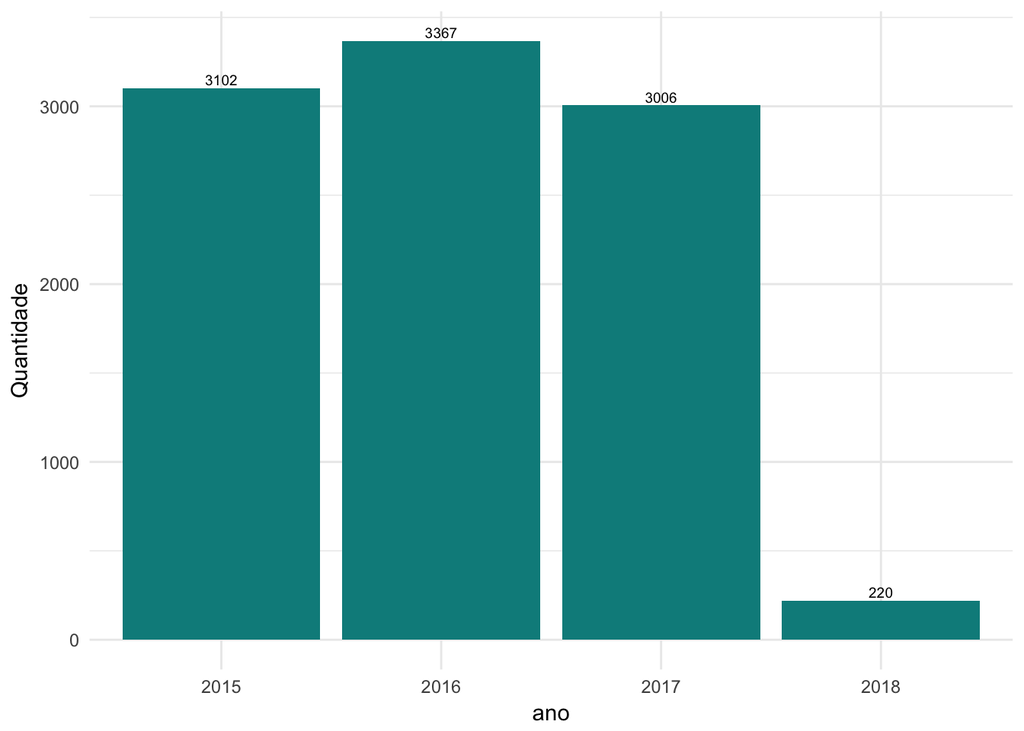

```r
infperiodicosZika %>%
group_by(ano) %>%
summarise(Quantidade = n()) %>%
ggplot(aes(x = ano, y = Quantidade)) +
geom_bar(position = "stack",stat = "identity", fill = "darkcyan")+
geom_text(aes(label=Quantidade), vjust=-0.3, size=2.5)+
theme_minimal()
```

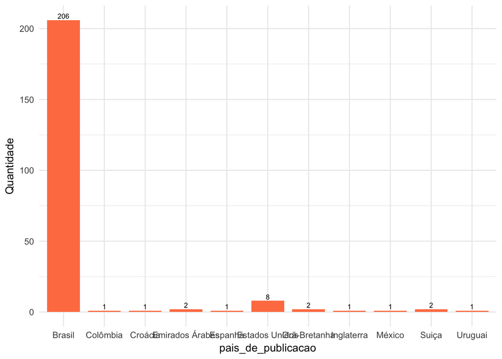

```r
inflivrosZika %>%
group_by(pais_de_publicacao) %>%
summarise(Quantidade = n()) %>%
ggplot(aes(x = pais_de_publicacao, y = Quantidade)) +
geom_bar(width=0.8, height = 0.3, position = "stack",stat = "identity", fill = "coral")+
geom_text(aes(label=Quantidade), vjust=-0.3, size=2.5) +
theme_minimal()
```

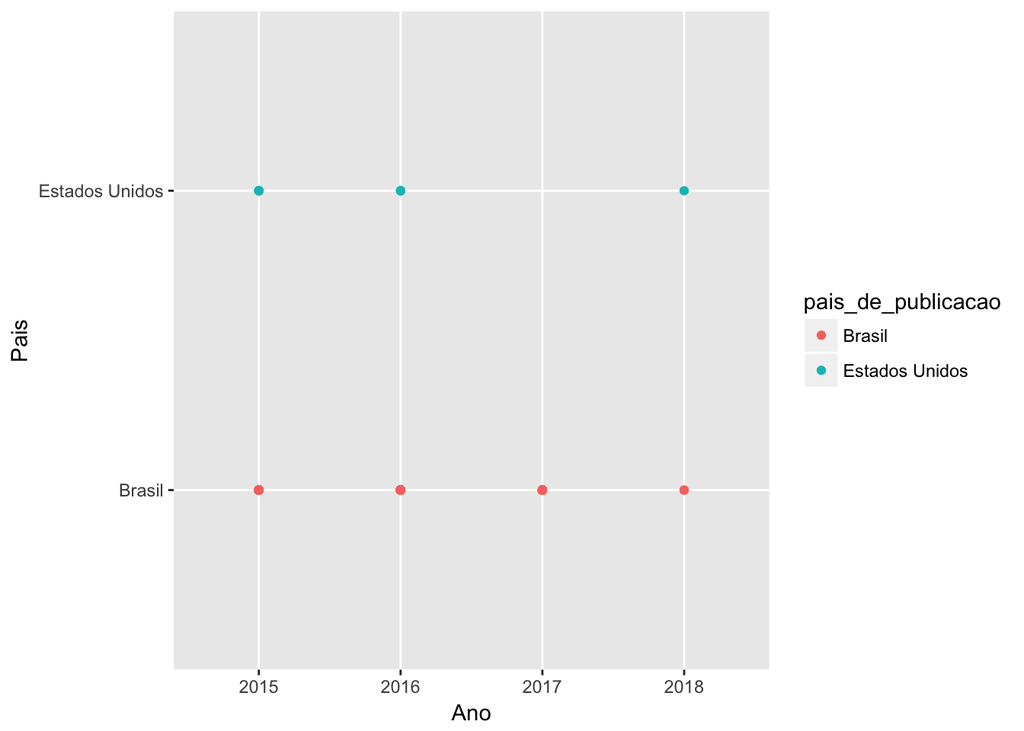

```r
inflivrosZika %>%
filter(pais_de_publicacao %in% c("Brasil", "Estados Unidos", "Holanda",
"Grã-Bretanha", "Alemanha", "Suiça")) %>%
group_by(ano,pais_de_publicacao) %>%
ggplot(aes(x=ano,y=pais_de_publicacao, color= pais_de_publicacao)) +
xlab("Ano") + ylab("Pais") + geom_point()
```

[figure not shown]

```r
ggplot(dfautoresZika, aes(x = Freq, y = Var1, color=Var1)) +
xlab("QUANTIDADE") + ylab("Autor") + geom_point()
```

O gráfico acima mostra os autores de livros em função do número de suas publicações.

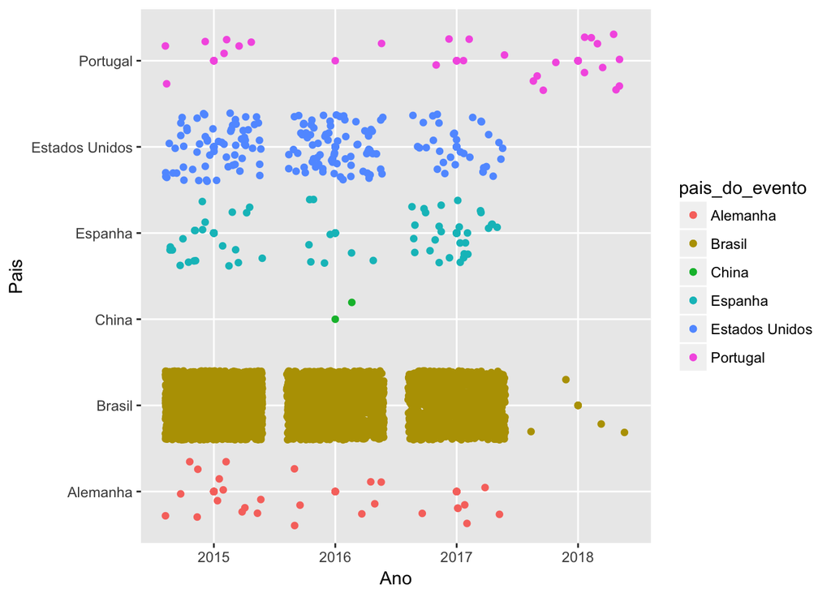

```r
infeventosZika %>%
filter(pais_do_evento %in% c("Brasil", "Estados Unidos", "Japão", "Colômbia",
"Venezuela", "Portugal", "Grã-Bretanha", "França",
"Espanha", "China", "Alemanha")) %>%
group_by(ano_do_trabalho,pais_do_evento) %>%
ggplot(aes(x=ano_do_trabalho,y=pais_do_evento, color= pais_do_evento)) +
xlab("Ano") + ylab("Pais") + geom_point() + geom_jitter()
```

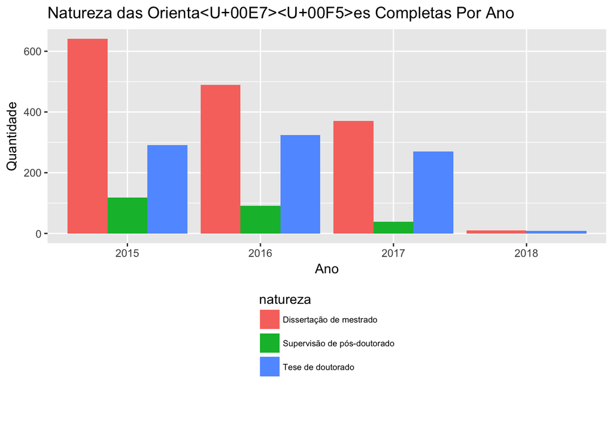

```r
ggplot(orientacaoCompletaZika,aes(ano,fill=natureza)) +
geom_bar(stat = "count", position="dodge") +
ggtitle("Natureza das Orientações Completas Por Ano") +
theme(legend.position="bottom",legend.text=element_text(size=7)) +
guides(fill=guide_legend(nrow=5, byrow=TRUE, title.position = "top")) +
labs(x="Ano",y="Quantidade")
```

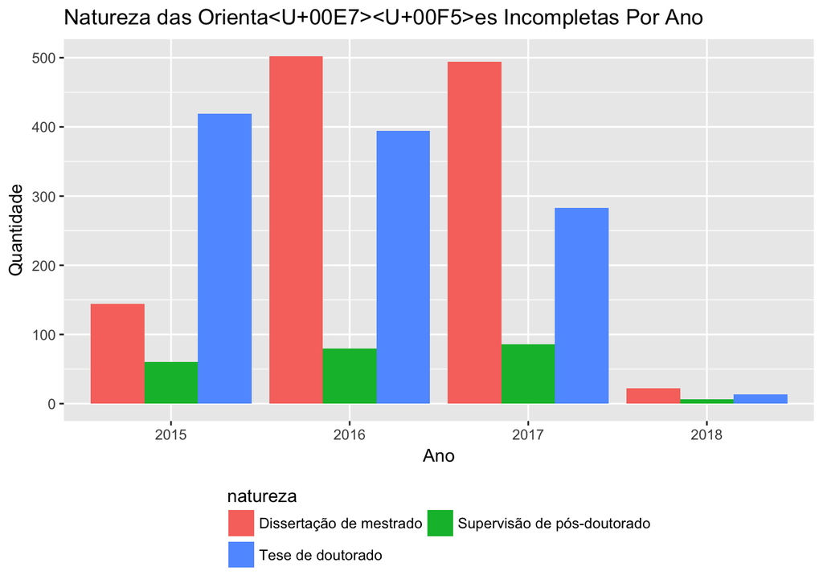

```r
ggplot(orientacaoIncompletaZika,aes(ano,fill=natureza)) +
geom_bar(stat = "count", position="dodge") +
ggtitle("Natureza das Orientações Incompletas Por Ano") +
theme(legend.position="bottom",legend.text=element_text(size=9)) +
guides(fill=guide_legend(nrow=2, byrow=TRUE, title.position = "top")) +
labs(x="Ano",y="Quantidade")
```

Quanto às orientações incompletas, é possível perceber que o número de orientações de doutorado que aparece nesse gráfico é relativamente maior do que o número que apareceu no gráfico anterior. Um forte indicador do porquê disso acontecer é a maior complexidade de uma pesquisa necessária para a escrita de tese de doutorado.

[figure not shown]

```r
ggplot(df_orientadores1Zika, aes(x=Var1, y=Freq)) +
geom_point(size=3) +
geom_segment(aes(x=Var1,
xend=Var1,
y=0,
yend=Freq)) +
labs(title="Número de Orientações por Professor", x="Lattes do Professor",
y="Número de Orientações") +
theme(axis.text.x = element_text(angle=75, vjust=0.6))
```

O gráfico acima mostra o número de orientações por professor com base em seu identificador de Lattes. Percebe-se que o número de orientações é bastante variado.

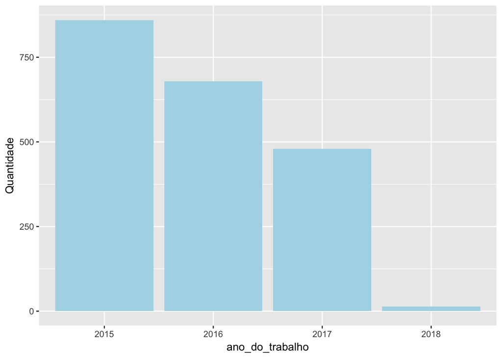

```r
pubZika %>%
group_by(ano_do_trabalho) %>%
summarise(Quantidade=n()) %>%
ggplot(aes(x=ano_do_trabalho, y=Quantidade)) +
geom_bar(stat="identity", fill="lightblue")
```

## Conclusão

Por meio desse trabalho, foi possível ter uma noção mais real de como é trabalhar com a ciência de dados e deixar ainda mais claro a importância de ferramentas de análise. Foi possível perceber como boa parte do tempo empregado é gasto analisando a estrutura dos dados obtidos e bolando estratégias para que se adquira aquilo que realmente importa. Também, há de se ressaltar, como é gratificante atingir o objetivo que se planeja ao iniciar a análise, possibilitando um entendimento maior do que se está estudando. No caso, foi possível diminuir o escopo dos nossos dados, filtrar por informações particulares, plotar gráficos para facilitar a visualização, e, de forma geral, conhecer um volume de dados expressivo com uma pequena análise quantitativa e qualitativa feita em cima dele.